# Exam 3 Practice 1, Problem 2: CNN Solution

Son Nguyen

## Problem 2: The Image and the Questions

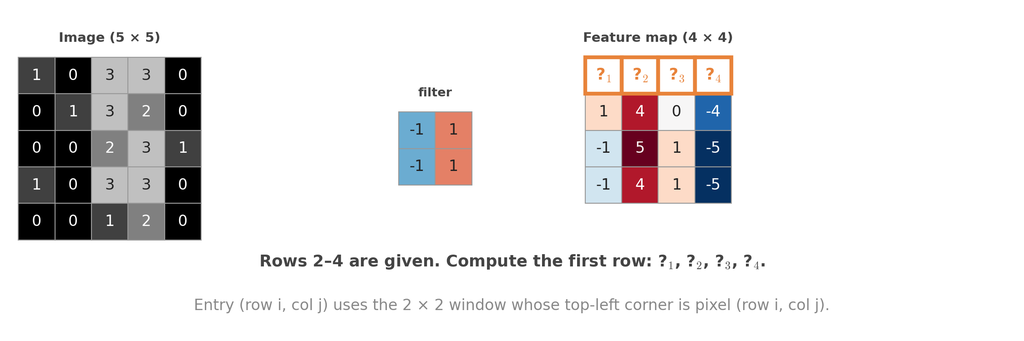

**Present your solution the way the sample solution does:** draw the grids of squares and the network, and write each calculation next to the drawing.

1. Compute the first row of the feature map, $?_1$, $?_2$, $?_3$ and $?_4$. For each one, draw the image as a grid of squares and box the $2 \times 2$ window, then write out filter × window (multiply the matching numbers and add).
2. Apply ReLU to the feature map, then $2 \times 2$ max pooling to get a $2 \times 2$ map. Draw the feature map, the map after ReLU, and the pooled map as grids of squares. Outline the four $2 \times 2$ pooling blocks and write the max of each block.
3. Flatten the pooled map row by row into $\mathbf{a} = (a_1, a_2, a_3, a_4)$. Draw $\mathbf{a}$ as a row of 4 squares.
4. Dense layer: $z_A = 0.2a_1 + 0.2a_3$ and $z_B = a_2 + a_4$ (biases 0). Draw the network: 4 input nodes $a_1, \dots, a_4$, 2 output nodes $z_A, z_B$, and a line from each input to each output labeled with its weight (dashed for weight 0). Compute both scores.
5. Softmax: compute $p_A$ and $p_B$. Use $e^1 \approx 2.72$ and $e^2 \approx 7.39$. Add the softmax step to your network drawing: an arrow from each score to its probability node. Which class is predicted?

## Solution (a): The First Row, Window by Window

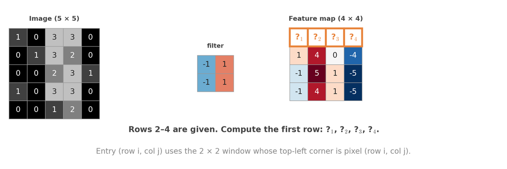

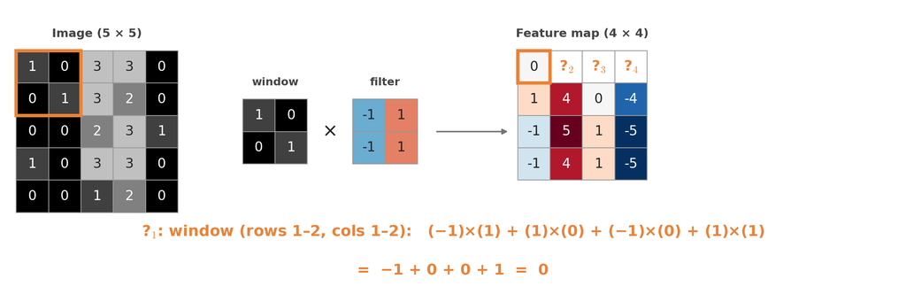

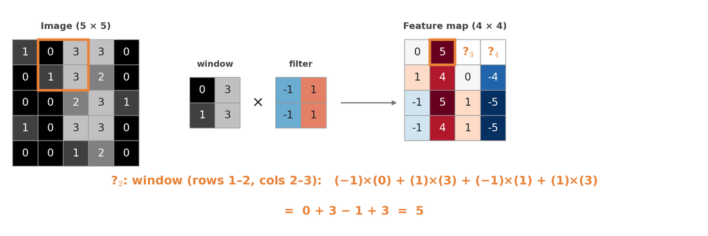

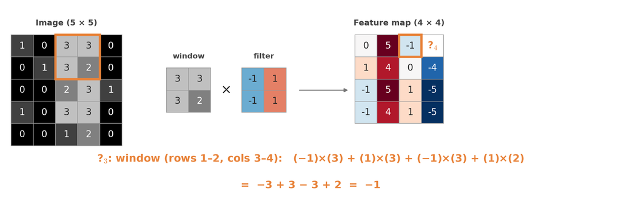

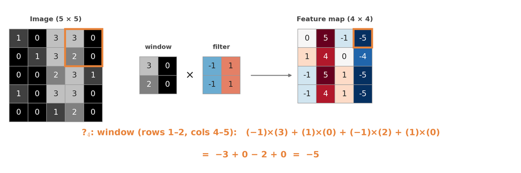

## Solution (b): ReLU, Number by Number

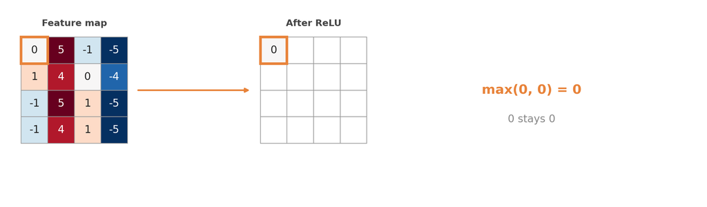

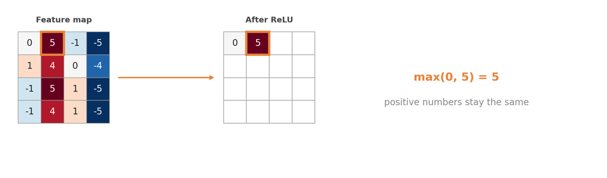

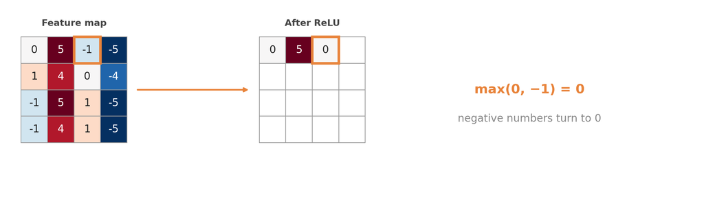

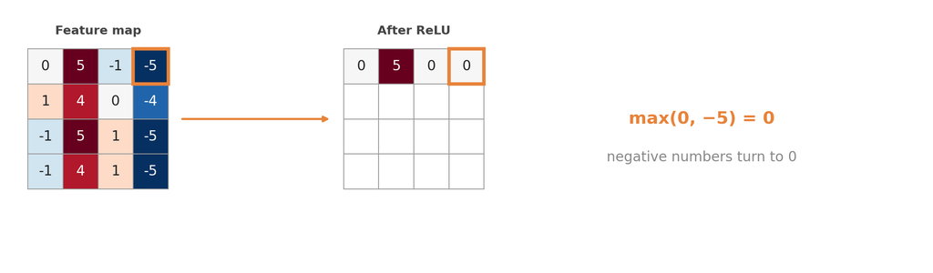

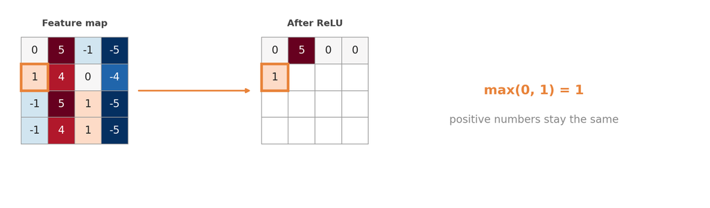

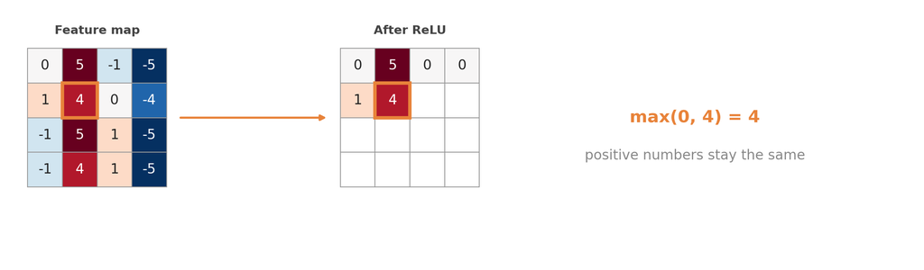

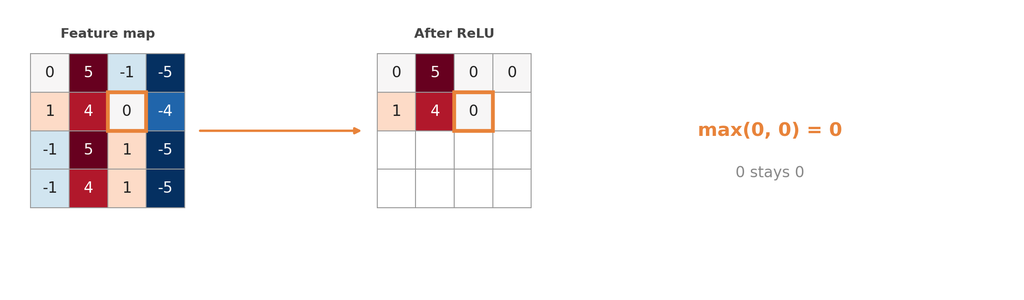

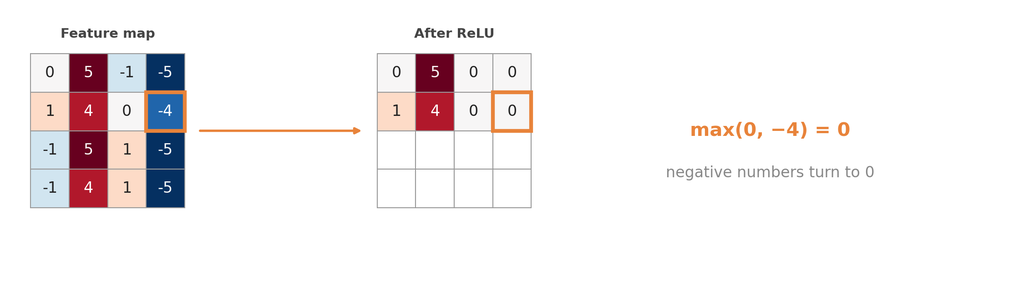

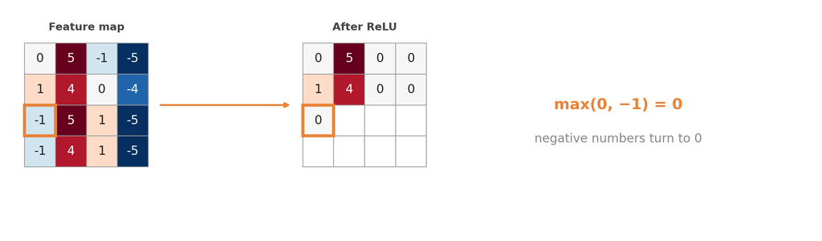

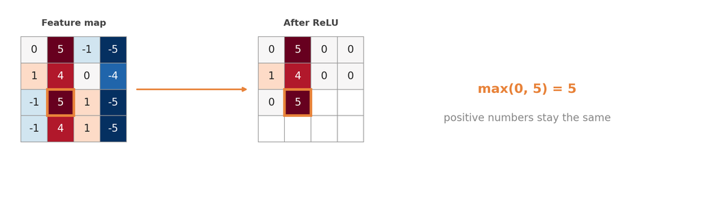

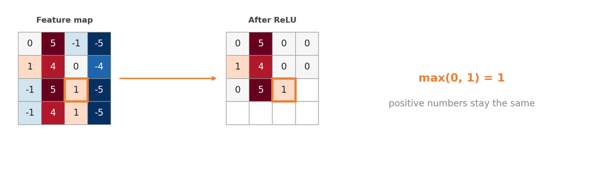

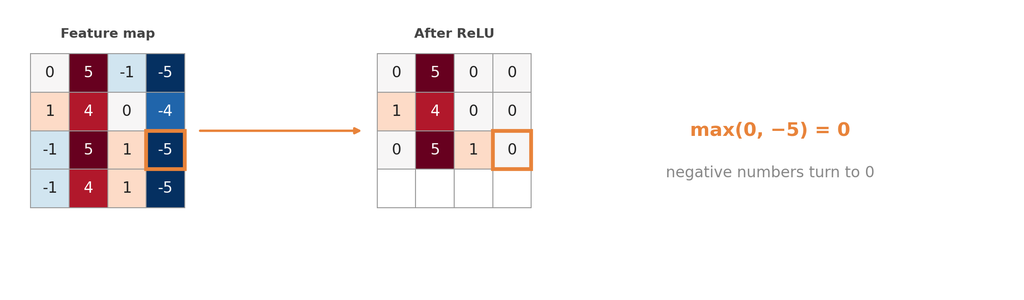

[4 more figures not shown]

## Solution (b, c): Pooling and Flatten, Block by Block

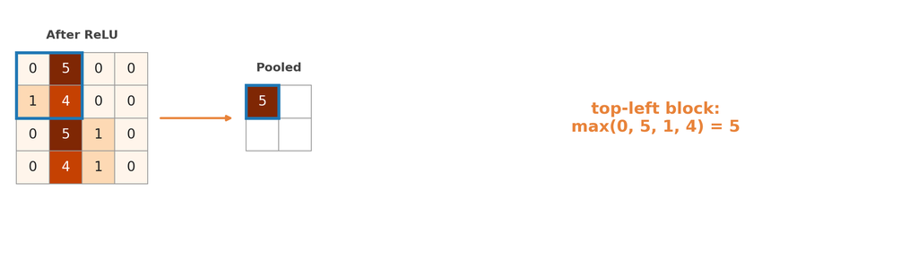

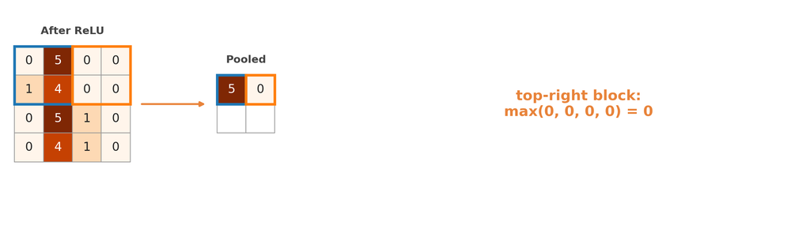

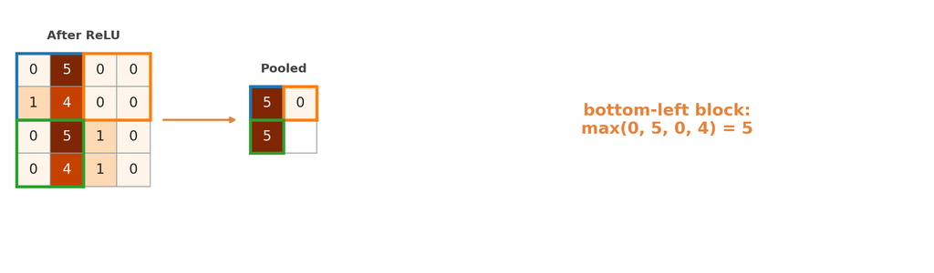

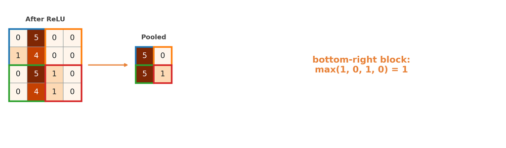

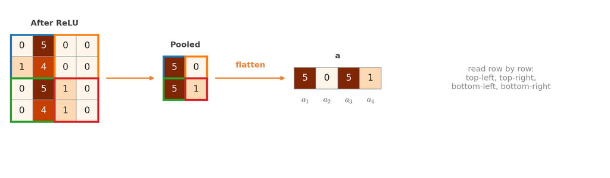

## Solution (d, e): Dense Layer and Softmax

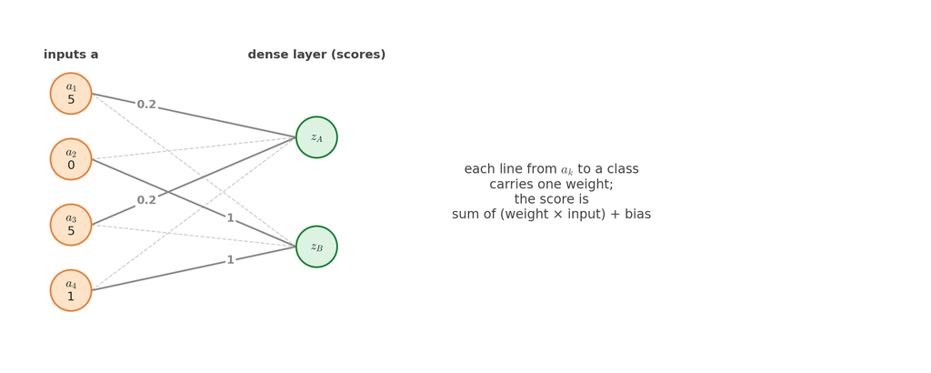

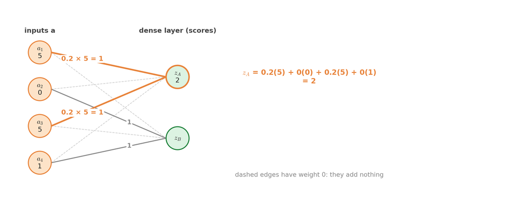

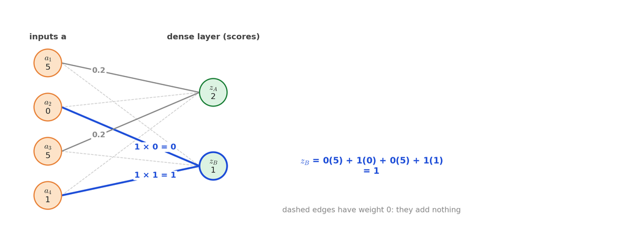

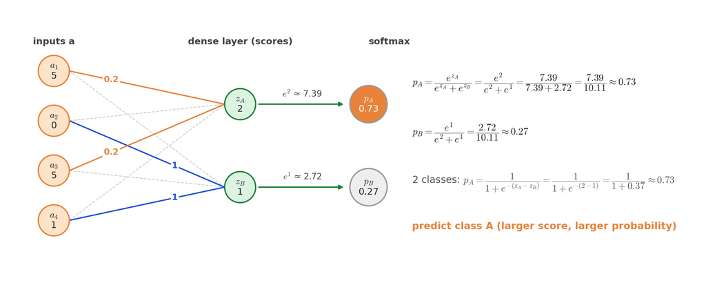